# A Practical Introduction to Propensity Score Analysis using R

## [4] Discipline-specific PS Systematic Reviews

- Propensity score matching most popular
  - Cardiovascular / Infective endocarditis / Intensive care
  - Critical care / anesthesiology / Sepsis / Psychology
  - Cancer / Multiple sclerosis
- Not meta-analysis; but reviews of usage of PS methods in different disciplines

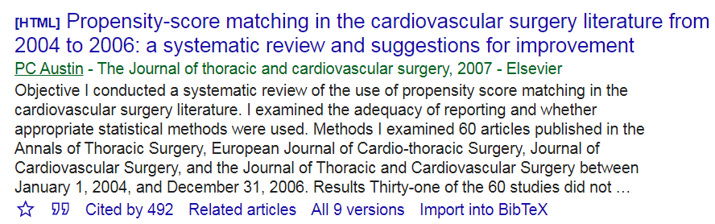

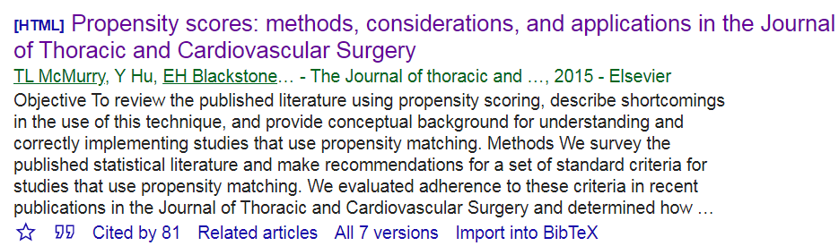

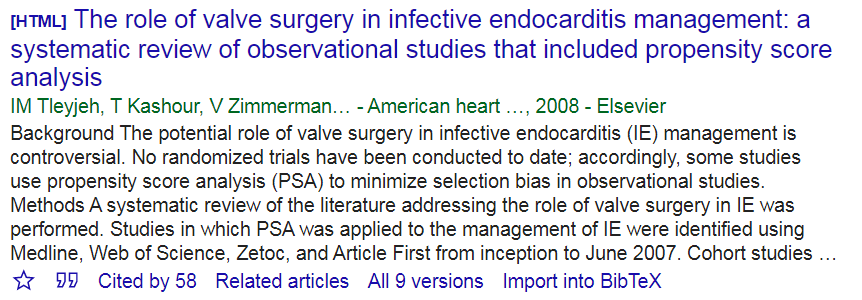

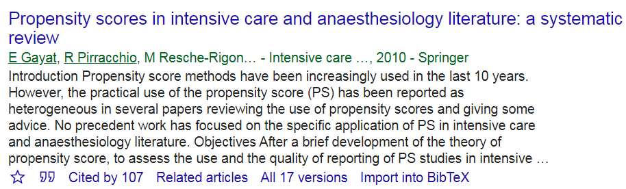

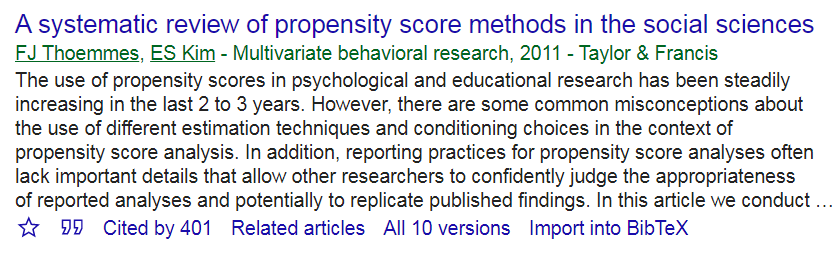

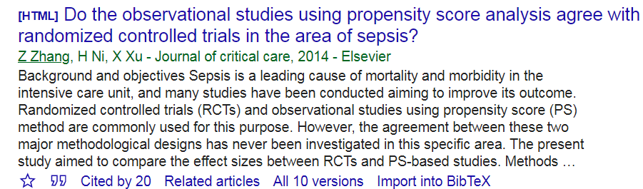

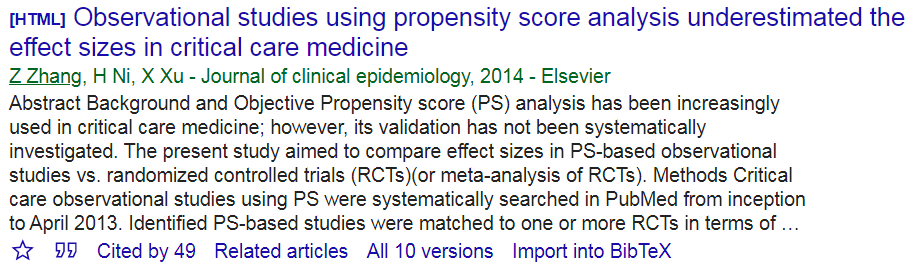

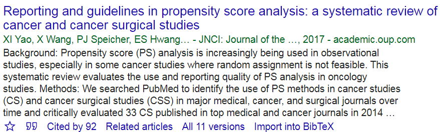

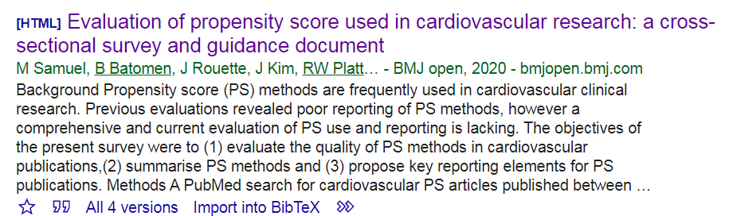

## [4] Discipline-specific PS Systematic Reviews

### Reporting Guideline

- Be specific about population of interest
  - ATT vs. ATE
  - exclusion criteria
- Be specific about exposure
  - no multiple version of treatment
  - no interference
  - comparator
- Report clearly about missing data
  - how handled
- Why PS matching (or other approach) was selected?
- Software

## [4] Discipline-specific PS Systematic Reviews

### Reporting Guideline

- How variables selected
- Any important variables not measured
  - proxy
- Model selection
  - interaction or polynomials
  - logistic vs. machine learning
- Overlap vs. balance
  - numeric and visual

[figure not shown]

## [4] Discipline-specific PS Systematic Reviews

### Reporting Guideline

- Reduction % of the matched data: main objection against this method!
- Residual imbalance
  - refit PS model
- Subgroup analysis
  - Refit within each group for matching
- Sensitivity analysis
  - unmeasured confounder / hdPS
  - any positivity issue? Deleting extremes has consequences!
    - ad-hoc methods: truncation / trimming: bias-variance trade-off

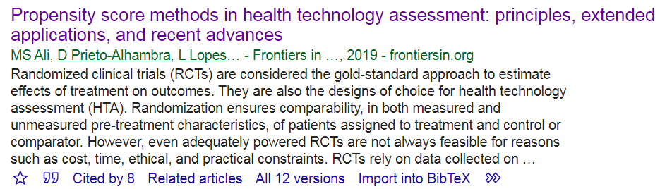

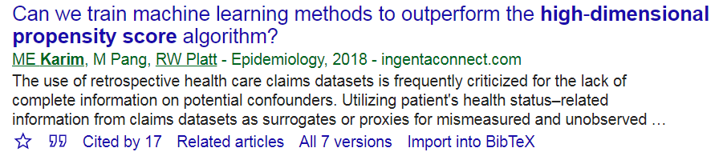

## Further Reading

[figure not shown]

[figure not shown]

Companion site: study.sagepub.com/leite

## Thank you!

ehsank.com/workshops/